# Data Augmentation

By Zoya Jamadar

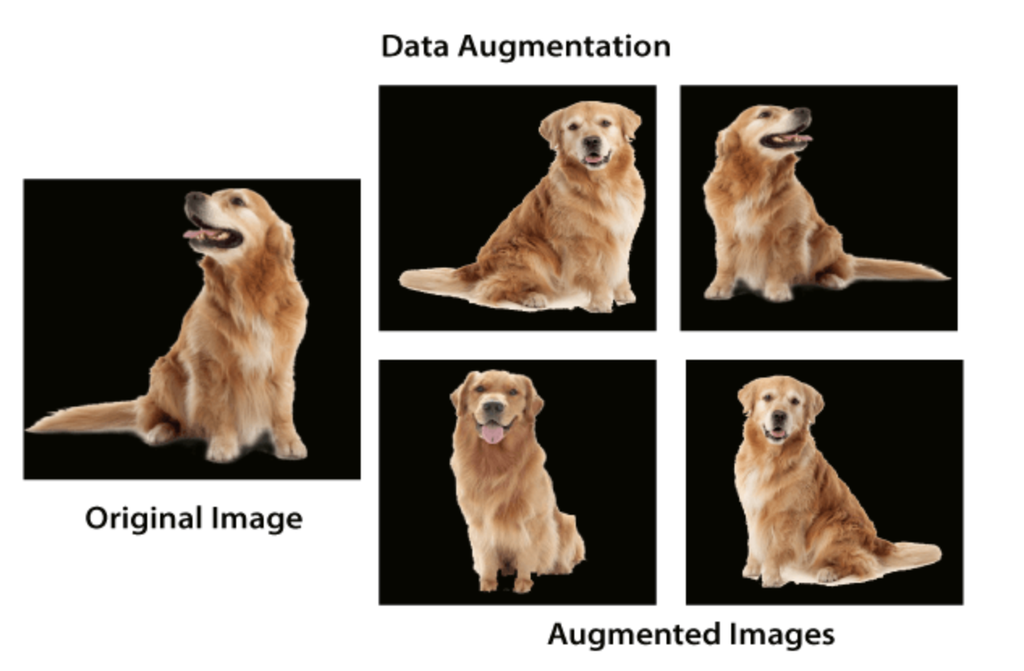

- Data augmentation is a technique used in machine learning and computer vision to increase the size of a training dataset by creating modified or enhanced versions of the original data samples.

The goal of data augmentation is to provide the learning algorithm with more diverse examples to learn from, which can improve the accuracy and generalization of the model. It can also help to reduce overfitting, where a model learns to memorize the training data instead of generalizing to new, unseen data.

Common techniques used in data augmentation include:

Image transformations, such as rotation, flipping, cropping, and scaling. Adding noise or distortion to the data, such as Gaussian noise, speckle noise, or random jittering. Applying color or brightness adjustments to the data, such as changing the hue, saturation, or contrast of an image. Data augmentation can be applied in real-time during model training, or preprocessed to create an augmented dataset before training. It is often used in computer vision tasks such as object detection, image classification, and segmentation, but can also be applied to other types of data, such as audio or text.

# Techniques of Data Augmentation

**We can augment the image data using various techniques. It can include:**

- Augmenting image data using **Geometric transformations** such as flipping, cropping, rotating, zooming, etc.
- Augmenting image data by using **Color transformations** such as by adjusting brightness, darkness, sharpness, saturation, etc.
- Augmenting image data by **random erasing, mixing images**, etc.

# Imgaug

Imgaug is an open-source python package that allows you to augment images in machine learning experiments. It works with a variety of augmentation techniques. It has a simple yet powerful interface and can augment images, landmarks, bounding boxes, heatmaps, and segmentation maps.

# Ipyplot

IPyPlot is a Python tool that allows for the fast and efficient display of images within Python Notebook cells. This package combines IPython with HTML to provide a quicker, richer, and more interactive way to show images. This package’s ‘plot_images’ command will be used to plot all of the images in a grid-like structure

```python
# download dependencies
!pip install imgaug
!pip install ipyplot
```

```python
# import libraries
import imageio
import imgaug as ia
import imgaug.augmenters as iaa
import ipyplot
```

```
        WARNING! Google Colab Environment detected!
        You might encounter issues while running in Google Colab environment.
        If images are not displaying properly please try setting `force_b64` param to `True`.
```

```python
input_img = imageio.imread('/content/Github.png')
```

show html

Original

Horizontally flipped

[figure not shown]

Vertically flipped

[figure not shown]

```python
#Horizontal Flip
hflip= iaa.Fliplr()
input_hf= hflip.augment_image(input_img)

#Vertical Flip
vflip= iaa.Flipud()
input_vf= vflip.augment_image(input_img)

images_list=[input_img, input_hf, input_vf]
labels = ['Original', 'Horizontally flipped', 'Vertically flipped']

ipyplot.plot_images(images_list,labels=labels,img_width=180)
```

show html

Original

Rotated Image

[figure not shown]

```python
# Rotation

rot1 = iaa.Affine(rotate=(-50,20))
input_rot1 = rot1.augment_image(input_img)

images_list=[input_img, input_rot1]
labels = ['Original', 'Rotated Image']
ipyplot.plot_images(images_list,labels=labels,img_width=180)
```

show html

Original

Cropped Image

[figure not shown]

```python
# Crop image

crop1 = iaa.Crop(percent=(0, 0.3))
input_crop1 = crop1.augment_image(input_img)

images_list=[input_img, input_crop1]
labels = ['Original', 'Cropped Image']
ipyplot.plot_images(images_list,labels=labels,img_width=180)
```

show html

Original

Gaussian Noise Image

[figure not shown]

```python
# Add noise to the image

noise=iaa.AdditiveGaussianNoise(10,40)
input_noise=noise.augment_image(input_img)

images_list=[input_img, input_noise]
labels = ['Original', 'Gaussian Noise Image']
ipyplot.plot_images(images_list,labels=labels,img_width=180)
```

**Why should we add noise to an image ?**

Adding noise (here gaussian noise) creates an optical illusion where the sharp tonal differences are highlighted across the pixels which make the image appear sharper without changing its resolution

show html

Original

Image Shearing

[figure not shown]

```python
# Shearing

shear = iaa.Affine(shear=(-80,80))
input_shear=shear.augment_image(input_img)

images_list=[input_img, input_shear]
labels = ['Original', 'Image Shearing']
ipyplot.plot_images(images_list,labels=labels,img_width=180)
```

**What is shearing ?**

'Shear' means that the image will be distorted along an axis, mostly to create or rectify the perception angles. It's usually used to augment images so that computers can see how humans see things from different angles

show html

Original

Gamma Contrast

[figure not shown]

SigmoidContrast

[figure not shown]

LinearContrast

[figure not shown]

```python
# Create Contrast

contrast=iaa.GammaContrast((0.5, 2.0))
contrast_sig = iaa.SigmoidContrast(gain=(5, 10), cutoff=(0.4, 0.6))
contrast_lin = iaa.LinearContrast((0.6, 0.4))

input_contrast = contrast.augment_image(input_img)
sigmoid_contrast = contrast_sig.augment_image(input_img)
linear_contrast = contrast_lin.augment_image(input_img)

images_list=[input_img, input_contrast,sigmoid_contrast,linear_contrast]
labels = ['Original', 'Gamma Contrast','SigmoidContrast','LinearContrast']
ipyplot.plot_images(images_list,labels=labels,img_width=180)
```

**What is contrast ?**

- Contrast is the difference between the maximum and minimum pixel intensity of an image. Formula: Contrast = maximum pixel intensity - minimum pixel intensity
- Increasing contrat means increasing the sharpness while decreasing the contrast means softening the image. This is used to highlight the areas of intrest in an image.

show html

Original

elastic

[figure not shown]

polar

[figure not shown]

jigsaw

[figure not shown]

```python
# Transformation
elastic = iaa.ElasticTransformation(alpha=60.0, sigma=4.0)
polar = iaa.WithPolarWarping(iaa.CropAndPad(percent=(-0.2, 0.7)))
jigsaw = iaa.Jigsaw(nb_rows=20, nb_cols=15, max_steps=(3, 7))
input_elastic = elastic.augment_image(input_img)
input_polar = polar.augment_image(input_img)
input_jigsaw = jigsaw.augment_image(input_img)
images_list=[input_img, input_elastic,input_polar,input_jigsaw]
labels = ['Original', 'elastic','polar','jigsaw']
ipyplot.plot_images(images_list,labels=labels,img_width=180)
```